# Praca domowa 2

Bartosz Zabkowski

## Dane

Dane wykorzystane w Pracy domowej 2 opisują wycenę nieruchmości. Każda obserwacja jest pewną nieruchmością, która posiada informacje takie jak powierzchnia, liczba pokoi, liczba łazienek i wiele więcj. Opis wszystkich kolumn w pliku `README.md`.

## Zadanie 1

Jak wygląda rozkład ceny nieruchomości w poszczególnych kodach pocztowych na przestrzeni lat? Rozważamy kody pocztowe, które mają więcej niż 280 posiadłości.

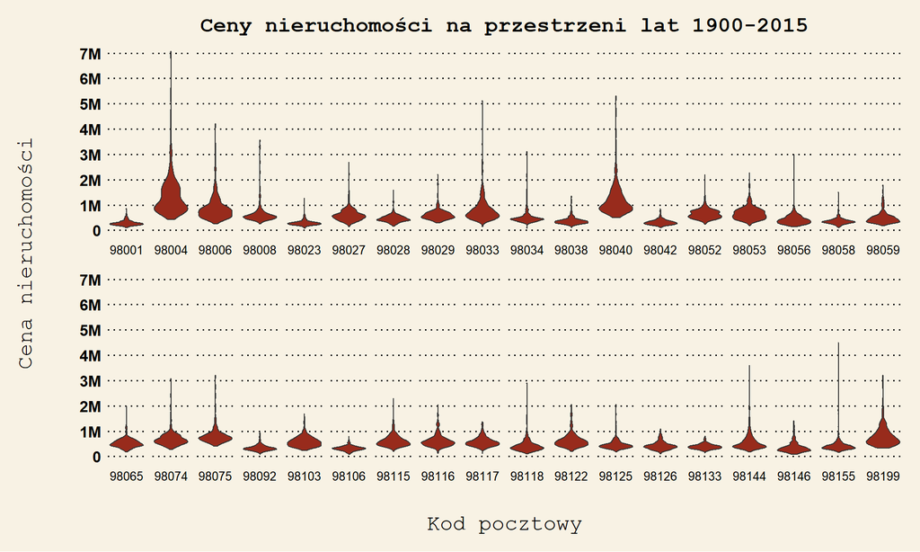

```r
# Tu umieść kod do wygenerowania odpowiedzi do zadania.

df%>%group_by(zipcode)%>%mutate(no_unique = n())%>%
  filter(no_unique>280)%>%
  ggplot(aes(y=price,x=1))+
  geom_violin(fill='#982B1C')+
  facet_wrap(~zipcode,nrow=2,switch="x")+
  theme_wsj()+
  scale_y_continuous(breaks = seq(0,max(df$price),by=1e6),
    labels = function(x) if_else(as.numeric(x)==0,"0",paste0(x/1e6,"M")))+
  theme(
    axis.text.x = element_blank(),
    axis.ticks.x = element_blank(),
    axis.line.x = element_blank(),
    axis.title.x = element_text(size = 17, margin = margin(t = 20)),
    axis.title.y = element_text(size = 17, margin = margin(r = 35)),
    plot.title = element_text(size=17,hjust = 0.5))+
  labs(
    x = "Kod pocztowy",
    y = "Cena nieruchomości",
    title = "Ceny nieruchomości na przestrzeni lat 1900-2015"
  )
```

## Zadanie 2

Czy jest różnica w rozkładzie ceny nierchomości od powierzchni mieszkalnej uwzględniając podział na nieruchomości z piwnicą i bez?

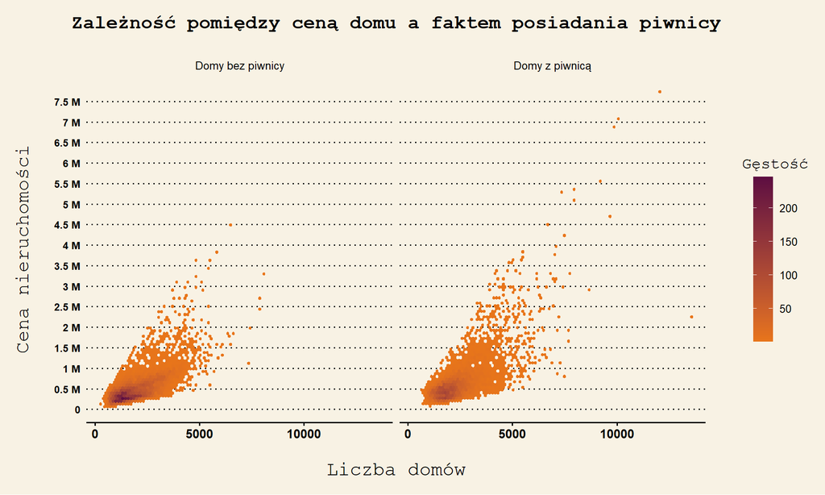

```r
# Tu umieść kod do wygenerowania odpowiedzi do zadania.

df%>%mutate(has_basement = ifelse(sqft_basement>0,"Domy z piwnicą","Domy bez piwnicy"))%>%ggplot(aes(x=sqft_living,y=price))+
  facet_wrap(~has_basement,ncol=2)+
  geom_hex(bins=100) +
  scale_fill_gradient(low = "#E8751A", high = "#5D0E41",guide=guide_colorbar(direction = "vertical",barheight=10,title.hjust=0.5),
                      name="Gęstość") +
  theme_wsj()+
  scale_y_continuous(breaks = seq(0,max(df$price),by=500000),
                     labels = function(x) ifelse(x>0,
                                                 paste(as.character(x/1e6),"M"),
                                                 "0"))+
  theme(
    plot.title = element_text(size=17,hjust=0.5,margin =margin(b=20)),
    legend.margin = margin(l=20),
    legend.title = element_text(size=14),
    axis.title.y = element_text(size=17,margin=margin(r=20)),
    axis.title.x = element_text(size=17,margin = margin(t=20)),
    axis.text.x = element_text(size=11),
    axis.text.y = element_text(size=9),
    legend.position = 'right'
  )+
  labs(
    title="Zależność pomiędzy ceną domu a faktem posiadania piwnicy",
    x = "Liczba domów",
    y = "Cena nieruchomości"
  )
```

**Komentarz:** Wykresy nie wykazują znaczącej różnicy pomiędzy rozkładem cen dla nieruchomości z piwnicami i bez nich. Jedynie w przypadku nieruchomości z piwnicami można zaobserwować większą tendencje do pojawienia się wartości odstających

## Zadanie 3

Jaka jest zależność pomiędzy jakością wykończenia nieruchomości a liczbą pięter?

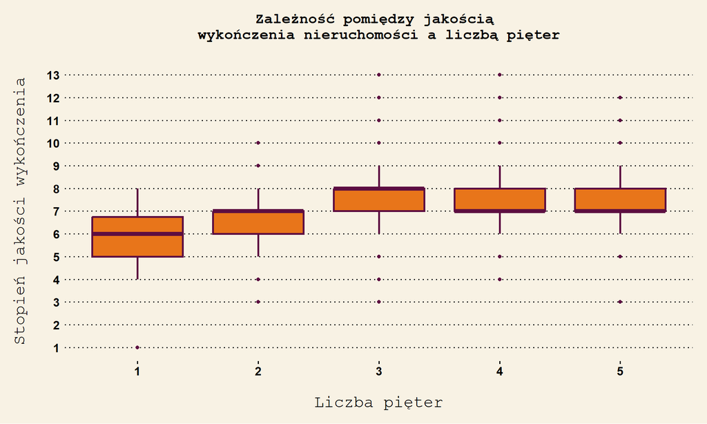

```r
# Tu umieść kod do wygenerowania odpowiedzi do zadania.

df%>%ggplot(aes(x=as.factor(condition),y=grade))+
  geom_boxplot(fill="#E8751A",color='#5D0E41',size=1)+
  theme_wsj()+
  scale_y_continuous(breaks = seq(0,max(df$grade),1),labels = function(x) x)+
  ggtitle("Zależność pomiędzy jakością \nwykończenia nieruchomości a liczbą pięter")+
  theme(axis.title.x = element_text(size=17,margin = margin(t=20)),
        axis.title.y = element_text(size=17,margin = margin(r=20)),
        plot.title = element_text(size=15,margin=margin(b=20),hjust=0.5),
        axis.line.x = element_blank())+
  labs(
    x="Liczba pięter",
    y="Stopień jakości wykończenia")
```

## Zadanie 4

Jaka jest zależność między powierzchnią mieszkalną nieruchomości a powierzchnią gruntu w podziale na liczbę sypialni?

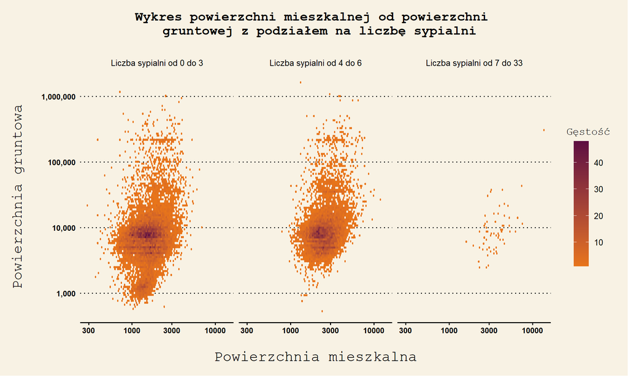

```r
# Tu umieść kod do wygenerowania odpowiedzi do zadania.


x<-df%>%mutate(type = ifelse(bedrooms <4,"Liczba sypialni od 0 do 3",
                                             ifelse(bedrooms<7,"Liczba sypialni od 4 do 6","Liczba sypialni od 7 do 33")))
ggplot(x, aes(x = sqft_living, y = sqft_lot)) +
  scale_x_log10() +
  scale_y_log10(labels = comma) +
  facet_wrap(~type, ncol = 3) +
  geom_hex(bins = 100) +
  scale_fill_gradient(low = "#E8751A", high = '#5D0E41',
                      guide = guide_colorbar(direction = "vertical",
                                             barheight = 10,
                                             title.hjust = 0.5),
                      name = "Gęstość") +
  theme_wsj() +
  ggtitle("Wykres powierzchni mieszkalnej od powierzchni \n gruntowej z podziałem na liczbę sypialni") +
  theme(plot.title = element_text(size = 15, margin = margin(b = 20), hjust = 0.5),
        legend.position = "right",
        legend.title = element_text(size = 12),
        axis.title.x = element_text(size = 17, margin = margin(t = 20)),
        axis.title.y = element_text(size = 17, margin = margin(r = 20)),
        axis.text.x = element_text(size=9),
        axis.text.y = element_text(size=9)) +
  labs(y = "Powierzchnia gruntowa",
       x = "Powierzchnia mieszkalna")
```

## Zadanie 5

Rozważmy tylko nieruchomości, które miały remont. W której dekadzie było najwięcej przeprowadzonych remontów? Czy w poszczególnych dekadach jest porównywalny procent nieruchmości dla każdej wartości miary jakości i wykończenia nieruchomości?

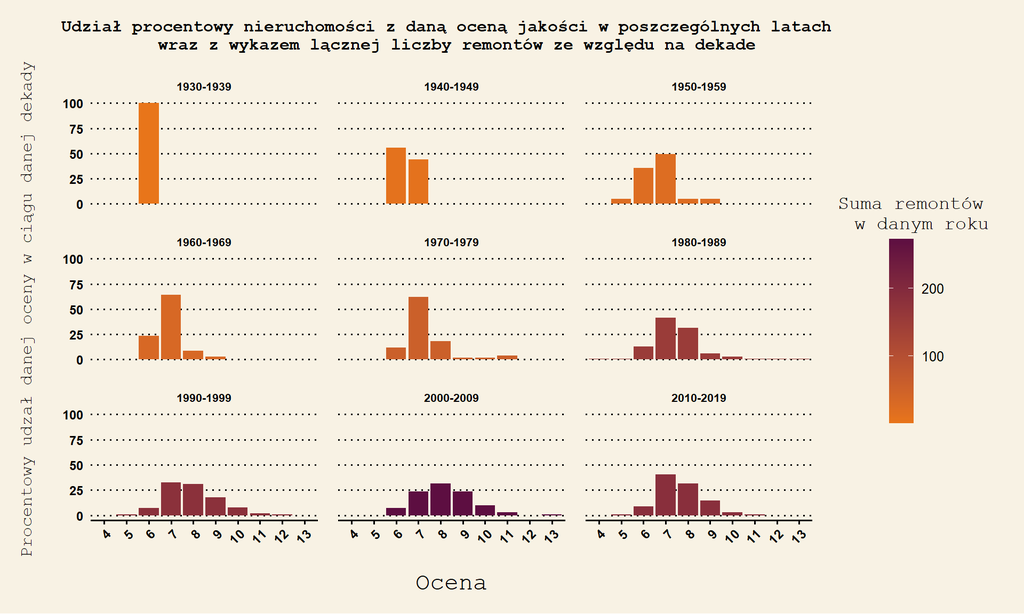

```r
# Tu umieść kod do wygenerowania odpowiedzi do zadania.

x<-df%>%filter(yr_renovated !=0)%>%mutate(temp = floor(yr_renovated/10))%>%group_by(temp)%>%
  mutate(decade = paste0(as.character(temp),"0-",as.character(temp),"9"),liczba_rem = n())%>%ungroup()%>%group_by(grade,decade)%>%
  mutate(no = n())

temp_data2 = as.data.frame.matrix(table(x$decade,x$grade))

temp_data2$decade = rownames(temp_data2)

temp_data2 <- temp_data2%>%group_by(decade)%>%mutate(decade_sum = sum(across(`4`:`13`)))%>%
  mutate(across(`4`:`13`,~ round((.x / decade_sum) * 100)))



q <-temp_data2%>%pivot_longer(cols = `4`:`13`,
                          names_to = "grade",
                          values_to = "count")%>%
  mutate(grade = as.numeric(grade))%>%
  mutate(grade = as.factor(grade))%>%group_by(decade_sum)%>%
  mutate(per = (count/sum(count))*100)%>%ungroup()

q%>%ggplot(aes(x=grade,y=per,fill=decade_sum))+
  geom_col()+
  facet_wrap(~decade,ncol=3)+
  theme_wsj()+
  scale_fill_gradient(low = "#E8751A", high = '#5D0E41',,guide = guide_colorbar(direction = "vertical",
                                                                     barheight = 9,
                                                                     title.hjust = 0.5),
                                                                      name = "Suma remontów \n w danym roku")+
  theme(
    axis.text.y = element_text(size=9),
    axis.text.x = element_text(angle = 45, hjust = 1,size=9),
    strip.background = element_blank(),
    strip.text = element_text(
      size = 8,
      face = "bold"),
    panel.spacing = unit(1, "lines"),
    legend.position = "right",
    legend.title = element_text(size=13),
    axis.title.y = element_text(size = 12, margin = margin(r = 20)),
    axis.title.x = element_text(size = 17, margin = margin(t = 20)),
    plot.title = element_text(size = 12, margin = margin(b = 15),hjust=0.5)
  )+
  ggtitle("Udział procentowy nieruchomości z daną oceną jakości w poszczególnych latach \n wraz z wykazem lącznej liczby remontów ze względu na dekade")+
  labs(
    y="Procentowy udzał danej oceny w ciągu danej dekady",
    x="Ocena")
```

**Komentarz:** Rozkład procentowy wartości grade w ostatnich trzech dekadach wyglądają dość podobnie. W zdecyowanej większości dekad najwięcej nieruchomości posiadało ocene 7 lub 6. Dekadą w której to było najwięcej przeprowadzonych rementów była dekada 2000-2009

## Zadanie 6

Jak prezentuje się wartość minimalna, średnia i maksymalna ceny nieruchmości w podziele na rok budowy nieruchomości.

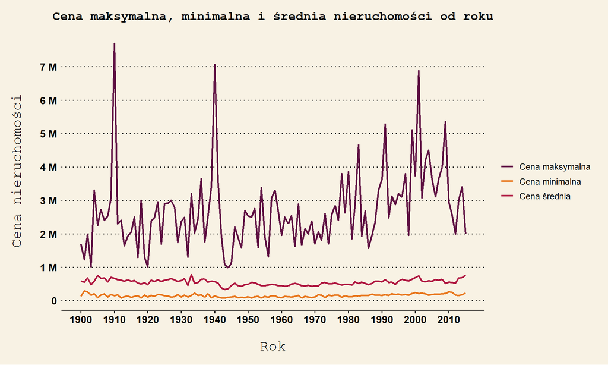

```r
# Tu umieść kod do wygenerowania odpowiedzi do zadania.

y<-df%>%group_by(yr_built)%>%mutate(min_price = min(price),max_price = max(price),mean_price = mean(price))
ggplot(data = y, aes(x = yr_built)) +
  geom_line(aes(y = min_price,color = "Cena minimalna"), size = 1) +
  geom_line(aes(y = max_price, color = "Cena maksymalna"), size = 1) +
  geom_line(aes(y = mean_price, color = "Cena średnia"), size = 1)+
  scale_y_continuous(breaks = seq(0,max(df$price),by=1000000),
                     labels = function(x) ifelse(x>0,
                                                 paste(as.character(x/1e6),"M"),
                                                 "0"))+
  scale_x_continuous(breaks = seq(0,max(df$yr_built),by=10))+
  scale_color_manual(values = c("Cena minimalna" = "#E8751A",
                                "Cena maksymalna" = "#5D0E41",
                                "Cena średnia" = "#AF1740"),
                     guide = guide_legend(
                       direction = "vertical",
                       title.hjust = 0.5,
                       title = ""
                     ))+
  theme_wsj()+
  theme(plot.title = element_text(size=15,margin=margin(b=10),hjust=0.5),
        axis.title.x = element_text(size=17,margin=margin(t=20)),
        axis.title.y = element_text(size=17,margin=margin(r=20)),
        legend.position = 'right',
        legend.text = element_text(size = 10),
        axis.text.x = element_text(size=12),
        axis.text.y = element_text(size=12))+
  labs(title = "Cena maksymalna, minimalna i średnia nieruchomości od roku",
       x="Rok",
       y="Cena nieruchomości")
```

**Komentarz:** Co interesujące, na przestrzeni około 100 lat cena minimalna jak i średnia właściwie pozostają na stałym poziomie czego nie można powiedzięc o cenie maksymalnej która zmienia się w czasie w sposób bardzo chaotyczny